# A toy example

Chao Zhou

8/4/2021

### Install and load fastANCOM

fastANCOM is a simple and easy to operate R package, it aims to perform analysis of compositional microbiome data (ANCOM) at a fast speed.

```r
# devtools::install_github('ZRChao/fastANCOM')
library(fastANCOM)
```

### The toy data

We take the differential abundance analysis of 2 groups for illustration. The data was generated from Poisson distribution for each group with 30 individuals and 100 microbes. We set the first 10 microbes to be differetial by multipling a effect size vector for the abundance of one group, which is the log2FC from a norm distribution $N(4, 1)$.

#### Data generation

```r
set.seed(110) # 123 lambs=10
data <- matrix(rpois(100*60, 10), 60)
b <- rnorm(10, 4)
data[31:60,1:10] <- t(t(data[31:60,1:10])*2^b)
group <- rep(c(0, 1), each=30)
rownames(data) <- paste0('sample', 1:60)
colnames(data) <- paste0('microbe', 1:100)
names(b) <- paste0('microbe', 1:10)

# take a look of the log2FC
kable_classic(kbl(t(round(b,4)),align= "c",caption='log2FC for the first 10 microbes'),
              html_font = "Cambria")
```

log2FC for the first 10 microbes

| microbe1 | microbe2 | microbe3 | microbe4 | microbe5 | microbe6 | microbe7 | microbe8 | microbe9 | microbe10 |
| --- | --- | --- | --- | --- | --- | --- | --- | --- | --- |
| 4.2367 | 5.3167 | 0.2592 | 4.7168 | 3.9631 | 4.4165 | 4.0121 | 3.2326 | 6.2298 | 4.3221 |

```r
# take a look of the data
kable_classic(kbl(data[1:10, 1:6], align = "c",  caption='Data at a glance'),
               full_width = T, html_font = "Cambria")
```

Data at a glance

|  | microbe1 | microbe2 | microbe3 | microbe4 | microbe5 | microbe6 |
| --- | --- | --- | --- | --- | --- | --- |
| sample1 | 10 | 5 | 8 | 7 | 13 | 16 |
| sample2 | 14 | 5 | 16 | 10 | 6 | 6 |
| sample3 | 12 | 12 | 12 | 12 | 12 | 10 |
| sample4 | 14 | 10 | 7 | 11 | 14 | 18 |
| sample5 | 11 | 7 | 10 | 10 | 9 | 20 |
| sample6 | 11 | 10 | 4 | 14 | 9 | 9 |
| sample7 | 9 | 14 | 6 | 7 | 18 | 11 |
| sample8 | 14 | 5 | 11 | 13 | 11 | 7 |
| sample9 | 4 | 13 | 15 | 13 | 12 | 10 |
| sample10 | 8 | 8 | 7 | 9 | 5 | 9 |

#### The comparison of the joint and marginal model

Before general simulation comparison, we first present some results of above toy data to show how fastANCOM works. We called the results calculated from the log-ratio-transformed data as the **Joint model** and the results constructed based on the results from the log-transformed data as the **Marginal model**. Figure below shows that the results calculated from marginal model are consistent to the results from joint model. The computation complexity is reduced from $O(K^2)$ for the joint model to $O(K)$ of the marginal model, where K is the number of microbes.

```r
n_otu <- ncol(data)
n_sample <- nrow(data)
logdata <- log2(data+0.5)
tmp <- lm(logdata ~ group)
sig <- 0.05
beta <- tmp$coefficients[2,]
xtx <- chol2inv(tmp$qr$qr[1:tmp$rank, 1:tmp$rank, drop = FALSE])
covbeta <- t(tmp$residuals) %*% tmp$residuals * xtx[2,2] /tmp$df.residual
beta.marginal <- beta - matrix(beta, nrow=n_otu, ncol=n_otu, byrow = T)
s12 <- matrix(diag(covbeta), nrow=n_otu, ncol=n_otu, byrow = T)
se.marginal <- sqrt(diag(covbeta) + s12 - 2*covbeta)
tstat.marginal <- -abs(beta.marginal/se.marginal)
ta <- qt(sig/2, df = n_sample-2)
W1.marginal <- rowSums(tstat.marginal < ta, na.rm = T)
```

```r
beta.joint <- beta.marginal
se.joint <- se.marginal
tstat.joint <- tstat.marginal
W1.joint <- W1.marginal
for(i in 1:n_otu) {
  tmp <- logdata[, i] - logdata[, -i]
  tmp <- lm(tmp ~ group)
  tt <- summary(tmp)
  tm <- sapply(1:length(tt), function(x) tt[[x]]$coefficients[2,1:2])
  beta.joint[i, -i] <- tm[1,]
  se.joint[i, -i] <- tm[2,]
}
tstat.joint <- -abs(beta.joint/se.joint)
W1.joint <- rowSums(tstat.joint < ta, na.rm = T)
diag(se.joint) <- diag(se.marginal) <- NA
```

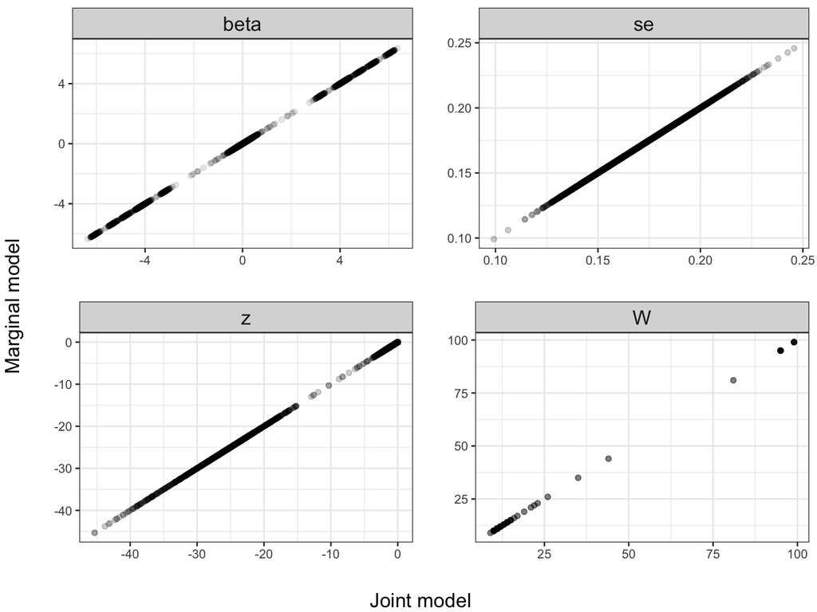

```r
resb12 <- data.frame(x=c(beta.joint,se.joint, tstat.joint, W1.joint),
                     y=c(beta.marginal, se.marginal,tstat.marginal, W1.marginal),
                     Type=c(rep(c('beta', 'se', 'z'),
                                each=length(beta.joint)), rep('W', n_otu)))
g1 <- ggplot(data=resb12[resb12$Type=='beta', ], aes(x=x, y=y)) +
  geom_point(alpha=0.1) + theme_bw() + facet_grid(.~Type, scales = 'free_y') +
  labs(x='', y='') + theme(strip.text.x = element_text(size=14))
g2 <- ggplot(data=resb12[resb12$Type=='se', ], aes(x=x, y=y)) +
  geom_point(alpha=0.1) + theme_bw() + facet_grid(.~Type, scales = 'free_y') +
  labs(x='', y='') + theme(strip.text.x = element_text(size=14))
g3 <- ggplot(data=resb12[resb12$Type=='z', ], aes(x=x, y=y)) +
  geom_point(alpha=0.1) + theme_bw() + facet_grid(.~Type, scales = 'free_y') +
  labs(x='', y='') + theme(strip.text.x = element_text(size=14))
g4 <- ggplot(data=resb12[resb12$Type=='W', ], aes(x=x, y=y)) +
  geom_point(alpha=0.5) + theme_bw() + facet_grid(.~Type, scales = 'free_y') +
  labs(x='', y='') + theme(strip.text.x = element_text(size=14))

g1234 <- ggarrange(g1, g2, g3, g4, nrow=2, ncol=2)
g1234 <- annotate_figure(g1234, bottom = text_grob('Joint model', size=14),
                         left = text_grob('Marginal model', rot = 90, size=14))
g1234
```

#### The reject number of each microbe

We can see that the reject number of different microbes are highly separable, i.e., the differential one gets large reject numbers (shown below). These findings motivate ANCOM to use the empirical distribution of $W$ to define a cutoff to make conclusion. In this example, the cutoff will be 94 with default setting and the third microbe ($W=81$) will not be detected. Although some hard cutoff (e.g., $0.7K$) was suggested in ANCOM-BC, it is difficult for ANCOM to do statistical inference, it does not provide p-value, standard errors, and confidence interval.

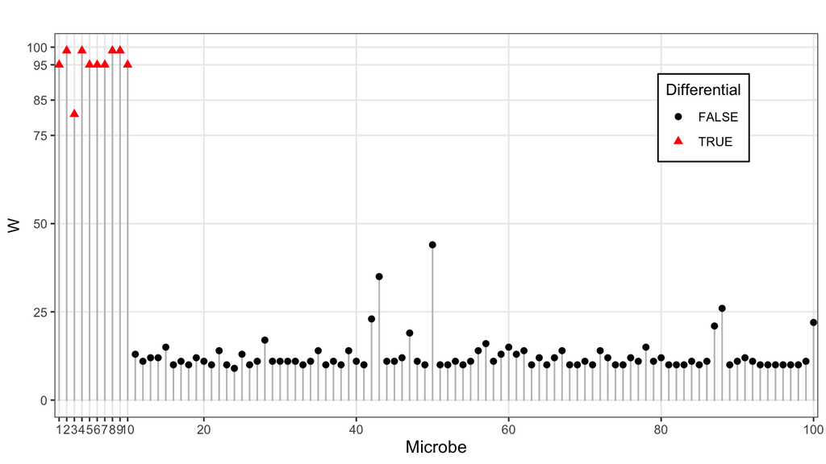

```r
wdata <- data.frame(W=W1.joint, Differential=c(rep(T, 10), rep(F, 90)))
wp <- ggplot(data=wdata, aes(x=factor(1:100),y=W,
                             color=Differential, shape=Differential)) +
  geom_bar(aes(y=W), stat = "identity", width = 0.005, color='grey') +
  # geom_vline(xintercept = 1:100, linetype='dashed', size=0.1) +
  scale_x_discrete(breaks = c(1:10,seq(20, 100, 20)))+
  scale_y_continuous(breaks = c(0, 25, 50, 75, 85, 95, 100), minor_breaks = NULL)+
  geom_point(size=2) + theme_bw() + labs(x='Microbe', title=' ') +
  scale_color_manual(values=c('black', 'red')) +
  # scale_colour_brewer(palette = "Set1", direction=1) +
  theme(legend.position = c(0.85, 0.78),
        axis.title.x = element_text(size=12),
        legend.background = element_rect(fill = "white", colour = "black"))
wp
```

#### The comparison of the joint model and the marginal model for the final log2 fold change estimation

While ANCOM detecting the differential microbes, fastANCOM chooses the non-differential microbes based on $W$. We consider that microbes with the least reject number are non-differential at the ecosystem level. Then the differential changes of each microbe between groups can be estimated based on the log ratio between the abundance of each microbe to the geometric mean of abundance of the non-differential microbes by the joint model. We also verified the following plot shows. Then the computation burden is limited to $O(K)$. Note that the third true differential microbe cannot be detected by ANCOM, fastANCOM gives a significance result ($p=5.38e-03$).

```r
rfn <- 0.05*n_otu
idx <- order(W1.joint)[1:rfn]

adj.beta <- beta - mean(beta[idx])
sers12 <- covbeta[idx, idx]
se0012 <- covbeta[, idx]
adj.se12 <- sqrt(diag(covbeta) - 2/rfn*rowSums(se0012) + sum(sers12)/rfn^2)
jpvs <- 2*pt(-abs(adj.beta/adj.se12), df=n_sample-2)


tmp <- logdata - rowMeans(logdata[, idx])
tmp <- lm(tmp ~ group)
tt <- summary(tmp)
tm <- sapply(1:length(tt), function(x) tt[[x]]$coefficients[2,1:2])
adj.betax <- tm[1, ]
adj.se12x <- tm[2, ]
jpvsx <- 2*pt(-abs(adj.betax/adj.se12x), df=n_sample-2)
```

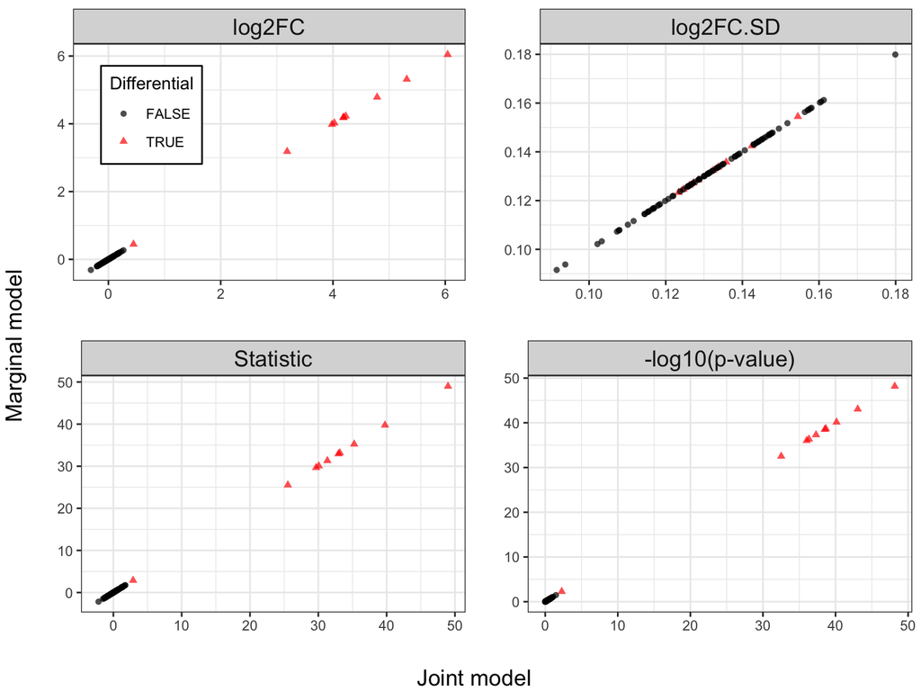

```r
resb12 <- data.frame(x=c(adj.beta,adj.se12, adj.beta/adj.se12, -log10(jpvs)),
                     y=c(adj.betax, adj.se12x,adj.betax/adj.se12x, -log10(jpvsx)),
                     Type=c(rep(c('log2FC','log2FC.SD','Statistic', '-log10(p-value)'),
                                each=n_otu)),
                     Differential=c(rep(T, 10), rep(F, 90)))

them1 <- theme_bw() + theme(strip.text.x = element_text(size=14), legend.position = 'none')

g5 <- ggplot(data=resb12[resb12$Type=='log2FC', ],
             aes(x=x, y=y,color=Differential, shape=Differential)) +
  geom_point(alpha=0.7) + facet_grid(.~Type, scales = 'free_y') +
  scale_color_manual(values=c('black', 'red')) + them1 + labs(x='', y='') +
  theme(legend.position = c(0.2, 0.7),
        legend.background = element_rect(fill = "white", colour = "black"))

g6 <- ggplot(data=resb12[resb12$Type=='log2FC.SD',],
             aes(x=x,y=y,color=Differential,shape=Differential)) +
  geom_point(alpha=0.7) + facet_grid(.~Type, scales = 'free_y') +
  scale_color_manual(values=c('black', 'red')) + them1 + labs(x='', y='')

g7 <- ggplot(data=resb12[resb12$Type=='Statistic', ],
             aes(x=x, y=y,color=Differential,shape=Differential)) +
  geom_point(alpha=0.7) + facet_grid(.~Type, scales = 'free_y') +
  scale_color_manual(values=c('black', 'red')) + them1 + labs(x='', y='')

g8 <- ggplot(data=resb12[resb12$Type=='-log10(p-value)', ],
             aes(x=x, y=y,color=Differential,shape=Differential)) +
  geom_point(alpha=0.7) + facet_grid(.~Type, scales = 'free_y') +
  scale_color_manual(values=c('black', 'red')) + them1 + labs(x='', y='')

g5678 <- ggarrange(g5, g6, g7, g8, nrow=2, ncol=2)
g5678 <- annotate_figure(g5678, bottom = text_grob('Joint model', size=14),
                         left = text_grob('Marginal model', rot = 90, size=14))
g5678
```

#### The output of fastANCOM

Here other parameters are set as default.

```r
fit <- fastANCOM(Y=data, x=group)
kable_classic(kbl(summary(fit), caption = 'Results summary'),
              full_width = T, html_font = "Cambria")
```

Results summary

|  | Length | Class | Mode |
| --- | --- | --- | --- |
| global | 0 | -none- | NULL |
| results | 3 | -none- | list |

```r
kable_classic(kbl(head(fit$results$final, 10), align = "c",
        caption='Results of fastANCOM'),  full_width = T, html_font = "Cambria")
```

Results of fastANCOM

|  | log2FC | log2FC.SD | log2FC.pval | log2FC.qval | Reject.number | REJECT |
| --- | --- | --- | --- | --- | --- | --- |
| microbe1 | 3.9819435 | 0.1324174 | 0.0000000 | 0.0000000 | 95 | TRUE |
| microbe2 | 5.3149871 | 0.1336755 | 0.0000000 | 0.0000000 | 99 | TRUE |
| microbe3 | 0.4467098 | 0.1544766 | 0.0053847 | 0.0538467 | 81 | TRUE |
| microbe4 | 4.7861659 | 0.1357929 | 0.0000000 | 0.0000000 | 99 | TRUE |
| microbe5 | 4.0251085 | 0.1285026 | 0.0000000 | 0.0000000 | 95 | TRUE |
| microbe6 | 4.2280714 | 0.1424813 | 0.0000000 | 0.0000000 | 95 | TRUE |
| microbe7 | 4.1822751 | 0.1261421 | 0.0000000 | 0.0000000 | 95 | TRUE |
| microbe8 | 3.1834985 | 0.1246453 | 0.0000000 | 0.0000000 | 99 | TRUE |
| microbe9 | 6.0430772 | 0.1233668 | 0.0000000 | 0.0000000 | 99 | TRUE |
| microbe10 | 4.1912823 | 0.1272263 | 0.0000000 | 0.0000000 | 95 | TRUE |

- Time comparison with the ANCOM used Wilcoxon rank-sum test **fastANCOM thousands of times faster than original ANCOM**

```r
system.time(replicate(100, fit <- fastANCOM(Y=data, x=group, effect = T)))
```

```
##    user  system elapsed
##   1.513   0.137   1.665
```

```r
system.time(replicate(100, fit <- fastANCOM(Y=data, x=group, effect = F)))
```

```
##    user  system elapsed
##   1.170   0.145   1.342
```

```r
system.time(replicate(1, fit <- ANCOM(Y=data, x=group, tfun = wilcox.test)))
```

```
##    user  system elapsed
##  27.049   0.457  28.955
```

- Results with plot

We present plots of reject number of each microbe, valcano plot, and the effect size estimation compared to the true settings.

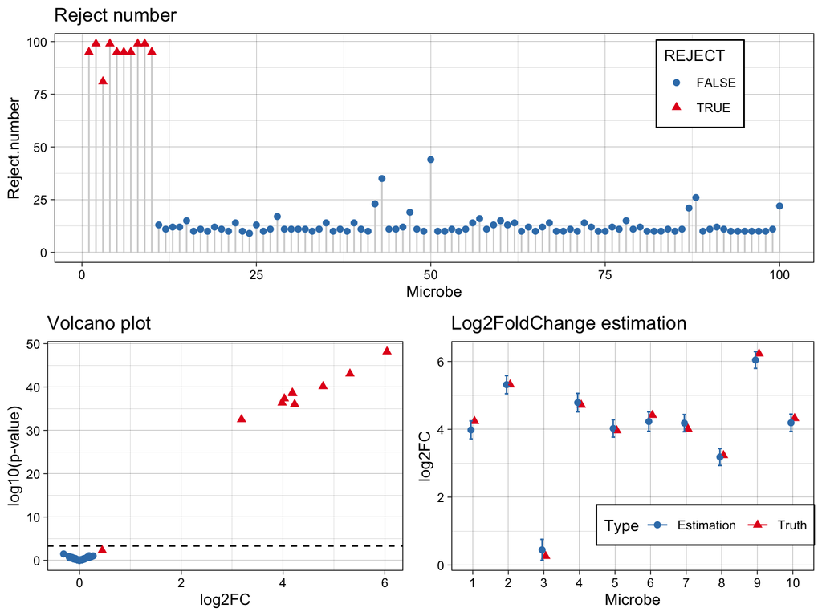

```r
fit <- fit$results$final
wp <- ggplot(data=fit, aes(x=1:100,y=Reject.number, color=REJECT, shape=REJECT)) +
  geom_bar(aes(y=Reject.number), stat = "identity", width = 0.005, color='lightgrey') +
  # geom_vline(xintercept = 1:100, linetype='dashed', size=0.1) +
  geom_point(size=2) + theme_linedraw() + labs(x='Microbe', title='Reject number') +
  scale_colour_brewer(palette = "Set1", direction=-1) +
  theme(legend.position = c(0.85, 0.78),
        legend.background = element_rect(fill = "white", colour = "black"))
vp <-ggplot(data=fit,aes(x=log2FC,y=-log10(log2FC.pval), color=REJECT, shape=REJECT)) +
  geom_hline(yintercept=-log10(0.05/nrow(fit)),
             linetype="dashed",color="black",size=0.5)+
  geom_point(size=2) + theme_linedraw() +
  labs(y='log10(p-value)', title='Volcano plot') +
  theme(legend.position='none') +
  scale_colour_brewer(palette = "Set1",direction=-1)

tmpb <- data.frame(Microbe=factor(1:10),log2FC=c(b, fit[1:10, 'log2FC']),
                   se=c(rep(0, 10), fit[1:10, 2]),
                   Type=c(rep('Truth', 10), rep('Estimation', 10)))
ep <- ggplot(data=tmpb, aes(x=Microbe, y=log2FC, color=Type, shape=Type))  +
  geom_point(size=2, position =  position_dodge(0.2) ) +
  geom_errorbar(aes(ymin=log2FC-2*se, ymax=log2FC+2*se),
                width=0.2, position =  position_dodge(0.2)) +
  theme_linedraw() + labs(title='Log2FoldChange estimation') +
  scale_colour_brewer(palette = "Set1", direction=-1) +
   theme(legend.position = c(0.7, 0.2), legend.direction = 'horizontal',
        legend.background = element_rect(fill = "white", colour = "black"))
figs <- ggarrange(wp, ggarrange(vp, ep, ncol=2), nrow=2)
figs
```

#### Comparison of different pseudo-count imputation for fastANCOM

We take 2 as the base of logarithm, then the estimated coefficient can explain as log2 fold change at the ecosystem level. However, it is meaningless to take logarithm of zeros. Many methods have been proposed for zero imputation. The above analysis for each joint and marginal linear model were done prior to add 0.5 for the abundance table, but the results may very sensitive to the choice of pseudo-count. As implemented in QIIME2, ANCOM adds the pseudo-count 1 to the abundance table before the log-ratio transformation. Expect structured zeros or some outliers, ANCOM-BC also adds 1 to the abundance table. Weiss, S., et al. (2017) adds an arbitrary pseudo-count value of 0.001 for ANCOM, when compare it to other differential abundance analysis methods.

Benefit from the fast computation of fastANCOM, we compared the effect of different choice of the pseudo-count for zero imputation. Besides using some equally pseudo-count (e.g., 0.001, 0.5, 1, 1.001) for all samples, we also consider a varied value for different samples, which equals to the total number of its reads divides to the maximum among them (denote as Depth/max(Depth)). The results are shown below. From this example, we can see that the estimated log2FC almost same across different imputations to the truth, but the standard error of adding 0.5 will be close to the true value in most cases. The p-value of adding 0.5, 1, and 1.001 are slight more significant than 0.001 and Depth/max(Depth). The effect of different pseudo-count imputation will be investigated more in the general simulations.

```r
fit0.001 <- fastANCOM(Y=data, x=group, pseudo = 0.001)
fit0.5 <- fastANCOM(Y=data, x=group, pseudo = 0.5)
fit1 <- fastANCOM(Y=data, x=group, pseudo = 1)
fit1.001 <- fastANCOM(Y=data, x=group, pseudo = 1.001)
a <- rowSums(data)/max(rowSums(data))
fita <- fastANCOM(Y=data, x=group, pseudo = a)
```

```r
fit0.001 <- fit0.001$results$final
fit0.5 <- fit0.5$results$final
fit1 <- fit1$results$final
fit1.001 <- fit1.001$results$final
fita <- fita$results$final
```

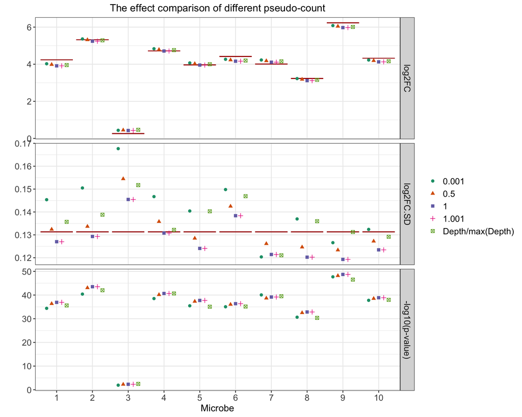

```r
pseudodata <- data.frame(Microbe=factor(1:10),
                         bs0 = c(rep(c(b, rep(sqrt(1/58),10), rep(NA, 10)), 5)),
bs=c(fit0.001$log2FC[1:10],fit0.001$log2FC.SD[1:10],-log10(fit0.001$log2FC.pval[1:10]),
  fit0.5$log2FC[1:10],fit0.5$log2FC.SD[1:10],-log10(fit0.5$log2FC.pval[1:10]),
  fit1$log2FC[1:10], fit1$log2FC.SD[1:10],-log10(fit1$log2FC.pval[1:10]),
  fit1.001$log2FC[1:10], fit1.001$log2FC.SD[1:10], -log10(fit1.001$log2FC.pval[1:10]),
       fita$log2FC[1:10], fita$log2FC.SD[1:10], -log10(fita$log2FC.pval[1:10])),
  t=c(rep(c('0.001', '0.5', '1', '1.001', 'Depth/max(Depth)'), each=10*3)),
  v=c(rep(rep(c('log2FC', 'log2FC.SD', '-log10(p-value)'), each=10), 5)))
pseudodata$v <- factor(pseudodata$v, levels=c('log2FC','log2FC.SD', '-log10(p-value)'))

gpseudo <- ggplot(data=pseudodata, aes(x=Microbe, y=bs, shape=t, color=t)) +
  geom_errorbar(aes(x=Microbe, y=bs0, ymax=bs0, ymin=bs0), colour="#AA0000")+
  geom_point(size=1.8, position = position_dodge(0.7)) +
  scale_color_brewer(palette = "Dark2") +
  facet_grid(v~., scale='free') + theme_bw() +
  labs(y='', title='The effect comparison of different pseudo-count') +
  theme(plot.title = element_text(size=14, hjust = 0.5),
        axis.title = element_text(size=13),
        strip.text.y = element_text(size=12), legend.title = element_blank(),
        axis.text =  element_text(size=12), legend.text = element_text(size=12))
gpseudo
```

#### Comparison of fastANCOM, ANCOM-BC and others methods

We compared the estimated differential changes of fastANCOM to other methods, including ALDEx2, DESeq2, edgeR, metagenomeSeq, and ANCOM-BC. Since the compositionality of microbiome data, we also compared them based the rarefied abundance table using the minimum sequencing depth among these samples.

##### a. Analysis based on the raw count data

- ANCOMBC

```r
library(ANCOMBC)
library(phyloseq)
library(magrittr)
meta0 <- data.frame(group=factor(group), row.names = rownames(data))
pseq.obj <- phyloseq(otu_table(t(data), taxa_are_rows = T), sample_data(meta0))
fit1 <- ancombc(phyloseq = pseq.obj, formula = "group",
                zero_cut = 0.90, lib_cut = 100,
                p_adj_method = "fdr",  group = "group")
summary(fit1)
```

```
##               Length Class      Mode
## feature_table   60   data.frame list
## zero_ind         0   -none-     NULL
## samp_frac       60   -none-     numeric
## resid         6000   -none-     numeric
## delta_em         1   -none-     numeric
## delta_wls        1   -none-     numeric
## res              6   -none-     list
## res_global       0   -none-     NULL
```

```r
ancombc_res <- data.frame(beta=fit1$res$beta$group1,se=fit1$res$se$group1,
                          z=fit1$res$W$group1,pval=fit1$res$p_val$group1,
                          qval=fit1$res$q_val$group1, detect=fit1$res$diff_abn$group1)
ancombc_res$beta <- log2(exp(ancombc_res$beta))
ancombc_res$se <- ancombc_res$se*log2(exp(1))
kable_classic(kbl(head(ancombc_res, 10), align = "c",
        caption='Results of ANCOM-BC'),  full_width = T, html_font = "Cambria")
```

Results of ANCOM-BC

| beta | se | z | pval | qval | detect |
| --- | --- | --- | --- | --- | --- |
| 3.912195 | 0.1127456 | 34.699310 | 0.0000000 | 0.000000 | TRUE |
| 5.240877 | 0.1233071 | 42.502656 | 0.0000000 | 0.000000 | TRUE |
| 0.426261 | 0.1251436 | 3.406174 | 0.0006588 | 0.006588 | TRUE |
| 4.711660 | 0.1060658 | 44.422067 | 0.0000000 | 0.000000 | TRUE |
| 3.954288 | 0.1150332 | 34.375197 | 0.0000000 | 0.000000 | TRUE |
| 4.163053 | 0.1257594 | 33.103309 | 0.0000000 | 0.000000 | TRUE |
| 4.109423 | 0.0991659 | 41.439882 | 0.0000000 | 0.000000 | TRUE |
| 3.115016 | 0.1207460 | 25.798079 | 0.0000000 | 0.000000 | TRUE |
| 5.974312 | 0.1085778 | 55.023335 | 0.0000000 | 0.000000 | TRUE |
| 4.127127 | 0.1098536 | 37.569344 | 0.0000000 | 0.000000 | TRUE |

- metagenomeSeq

```r
library(metagenomeSeq)
datz <- newMRexperiment(t(data),
    phenoData = AnnotatedDataFrame(data.frame(X = group, row.names = rownames(data))))
qua <- cumNormStatFast(datz)
new.data <- cumNorm(datz, p = qua)#
mod <- model.matrix(~1+X, data = pData(new.data))
res <- fitFeatureModel(new.data, mod)
zig_res <- MRcoefs(res, number = ncol(data))
zig_res <- zig_res[colnames(data), ]
zig_res$logFC <- log2(exp(zig_res$logFC))
zig_res$se <- zig_res$se *log2(exp(1))
kable_classic(kbl(head(zig_res, 10), align = "c",
        caption='Results of metagenomeSeq'),  full_width = T, html_font = "Cambria")
```

Results of metagenomeSeq

|  | logFC | se | pvalues | adjPvalues |
| --- | --- | --- | --- | --- |
| microbe1 | 4.0879543 | 0.5208786 | 0.0000000 | 0.0000000 |
| microbe2 | 5.4252031 | 0.5306220 | 0.0000000 | 0.0000000 |
| microbe3 | 0.5044554 | 0.5402073 | 0.3503978 | 0.9986928 |
| microbe4 | 4.8974153 | 0.4983791 | 0.0000000 | 0.0000000 |
| microbe5 | 4.1324274 | 0.5020946 | 0.0000000 | 0.0000000 |
| microbe6 | 4.3283171 | 0.5189532 | 0.0000000 | 0.0000000 |
| microbe7 | 4.2922092 | 0.4832332 | 0.0000000 | 0.0000000 |
| microbe8 | 3.2885981 | 0.5275246 | 0.0000000 | 0.0000000 |
| microbe9 | 6.1475272 | 0.5038284 | 0.0000000 | 0.0000000 |
| microbe10 | 4.2909554 | 0.5017476 | 0.0000000 | 0.0000000 |

- edgeR, which didn’t provide CI/sd

```r
library(edgeR)
temp <- DGEList(counts = t(round(data)), group = factor(group)) # glmQLFit()
edger_res  <- edgeR::calcNormFactors(temp) %>% estimateCommonDisp() %>%
  estimateTagwiseDisp %>% exactTest %>%  topTags(., n=nrow(.)) %>% .$table
edger_res <- edger_res[colnames(data), ]
kable_classic(kbl(head(edger_res, 10), align = "c",
        caption='Results of edgeR'),  full_width = T, html_font = "Cambria")
```

Results of edgeR

|  | logFC | logCPM | PValue | FDR |
| --- | --- | --- | --- | --- |
| microbe1 | 3.896182 | 15.53459 | 0.000000 | 0.0000000 |
| microbe2 | 5.238985 | 16.77656 | 0.000000 | 0.0000000 |
| microbe3 | 0.330418 | 12.72713 | 0.013049 | 0.1018446 |
| microbe4 | 4.716695 | 16.20001 | 0.000000 | 0.0000000 |
| microbe5 | 3.945449 | 15.53835 | 0.000000 | 0.0000000 |
| microbe6 | 4.176234 | 15.88256 | 0.000000 | 0.0000000 |
| microbe7 | 4.115937 | 15.62357 | 0.000000 | 0.0000000 |
| microbe8 | 3.098458 | 14.79975 | 0.000000 | 0.0000000 |
| microbe9 | 5.972724 | 17.57073 | 0.000000 | 0.0000000 |
| microbe10 | 4.143725 | 15.83587 | 0.000000 | 0.0000000 |

- DESeq2

```r
library(DESeq2)
coldata <- data.frame(row.names = rownames(data), condition=factor(group))
dds <- DESeqDataSetFromMatrix(countData=t(as.matrix(round(data))),
                              colData=coldata, design=~condition)
deseq2_res <- suppressMessages(DESeq(dds)) %>% results()
kable_classic(kbl(head(deseq2_res, 10), align = "c",
        caption='Results of DESeq2'),  full_width = T, html_font = "Cambria")
```

Results of DESeq2

|  | baseMean | log2FoldChange | lfcSE | stat | pvalue | padj |
| --- | --- | --- | --- | --- | --- | --- |
| microbe1 | 81.68910 | 3.9406380 | 0.1308094 | 30.125034 | 0.0000000 | 0.0000000 |
| microbe2 | 197.58341 | 5.2912601 | 0.1420762 | 37.242415 | 0.0000000 | 0.0000000 |
| microbe3 | 10.00707 | 0.3571709 | 0.1304652 | 2.737672 | 0.0061876 | 0.0247503 |
| microbe4 | 130.36283 | 4.7556214 | 0.1304934 | 36.443393 | 0.0000000 | 0.0000000 |
| microbe5 | 82.04349 | 3.9924721 | 0.1366135 | 29.224584 | 0.0000000 | 0.0000000 |
| microbe6 | 104.15803 | 4.2140061 | 0.1419614 | 29.684161 | 0.0000000 | 0.0000000 |
| microbe7 | 86.64915 | 4.1561902 | 0.1266342 | 32.820440 | 0.0000000 | 0.0000000 |
| microbe8 | 48.04006 | 3.1378668 | 0.1348802 | 23.264108 | 0.0000000 | 0.0000000 |
| microbe9 | 341.00824 | 6.0069149 | 0.1284118 | 46.778515 | 0.0000000 | 0.0000000 |
| microbe10 | 100.88274 | 4.1810213 | 0.1337843 | 31.251955 | 0.0000000 | 0.0000000 |

- ALDEx2

```r
library(ALDEx2)
x <- aldex.clr(t(round(data)), as.character(group))
x.tt <- aldex.ttest(x)
x.ee <- aldex.effect(x, CI=T)
aldex2_res <- data.frame(x.ee, x.tt)
# aldex2_res <- aldex(t(round(data)), as.character(group), test = "t", effect=T, CI=T)
kable_classic(kbl(head(aldex2_res[,6:13], 10), align = "c",
        caption='Results of ALDEx2'),  full_width = T, html_font = "Cambria")
```

Results of ALDEx2

|  | effect | effect.low | effect.high | overlap | we.ep | we.eBH | wi.ep | wi.eBH |
| --- | --- | --- | --- | --- | --- | --- | --- | --- |
| microbe1 | 4.514762 | 1.3273373 | 27.108790 | 0.0000366 | 0.0000000 | 0.0000000 | 0.0000000 | 0.0000000 |
| microbe2 | 5.879396 | 1.8670040 | 33.041554 | 0.0000366 | 0.0000000 | 0.0000000 | 0.0000000 | 0.0000000 |
| microbe3 | 0.065748 | -4.1077668 | 3.660338 | 0.4721499 | 0.6277977 | 0.6460328 | 0.6056638 | 0.6194983 |
| microbe4 | 5.582839 | 1.7822018 | 28.866167 | 0.0000366 | 0.0000000 | 0.0000000 | 0.0000000 | 0.0000000 |
| microbe5 | 4.183706 | 1.4532102 | 25.882965 | 0.0000366 | 0.0000000 | 0.0000000 | 0.0000000 | 0.0000000 |
| microbe6 | 4.323803 | 1.5126134 | 27.226814 | 0.0000366 | 0.0000000 | 0.0000000 | 0.0000000 | 0.0000000 |
| microbe7 | 4.975099 | 1.6075689 | 27.168776 | 0.0000366 | 0.0000000 | 0.0000000 | 0.0000000 | 0.0000000 |
| microbe8 | 3.179804 | 0.8761673 | 18.403946 | 0.0000366 | 0.0000000 | 0.0000000 | 0.0000000 | 0.0000000 |
| microbe9 | 7.131797 | 2.4497616 | 44.538578 | 0.0000366 | 0.0000000 | 0.0000000 | 0.0000000 | 0.0000000 |
| microbe10 | 4.759871 | 1.6454442 | 25.996491 | 0.0000366 | 0.0000000 | 0.0000000 | 0.0000000 | 0.0000000 |

```r
library(ggpmisc)
bmethods <- c('Truth','fastANCOM','ANCOM-BC','metagenomeSeq','ALDEx2',
                     'edgeR', 'DESeq2')
tmpb2 <- data.frame(x=b,y=c(fit0.5[1:10, 1],ancombc_res$beta[1:10],zig_res$logFC[1:10],
        aldex2_res$effect[1:10],edger_res$logFC[1:10],deseq2_res$log2FoldChange[1:10]),
        Type=c(rep(bmethods[-1], each=10)))
tmpb2$ymin<-c(fit0.5[1:10, 1]-2*fit0.5[1:10, 2],
              ancombc_res$beta[1:10]-2*ancombc_res$se[1:10],
              zig_res$logFC[1:10]-2*zig_res$se[1:10],
              aldex2_res$effect.low[1:10], rep(NA, 10),
              deseq2_res$log2FoldChange[1:10]-2*deseq2_res$lfcSE[1:10])
tmpb2$ymax<-c(fit0.5[1:10, 1]+2*fit0.5[1:10, 2],
              ancombc_res$beta[1:10]+2*ancombc_res$se[1:10],
              zig_res$logFC[1:10]+2*zig_res$se[1:10],
              aldex2_res$effect.high[1:10],rep(NA, 10),
              deseq2_res$log2FoldChange[1:10]+2*deseq2_res$lfcSE[1:10])
tmpb2$Type <- factor(tmpb2$Type, levels=bmethods[c(3:7,2)])
cos <- brewer.pal(12,"Paired")[-c(1,3,11)]
cos[c(7)] <- brewer.pal(11,"RdBu")[c(11)]
cos[c(5)] <- brewer.pal(12,"Paired")[c(12)]
cos[9] <- brewer.pal(8,"Dark2")[2]
cols <- cos[c(7:3,9)]

ep2 <- ggplot(data=tmpb2, aes(x=x, y=y, color=Type, shape=Type))  +
  geom_abline(intercept = 0, slope = 1) +
  geom_point(size=2, position =  position_dodge(0) ) +
  geom_errorbar(aes(ymin=ymin, ymax=ymax),
                width=0.2, position =  position_dodge(0)) +
  labs(x='True log2FC', y='Estimated log2FC',
       title='Results based on the raw generated data') +
  facet_wrap(.~Type, nrow=2, scales = 'free') +
  scale_color_manual(values = cols) + theme_bw() +
  # scale_colour_brewer(palette = "Set2", direction=1) +
  theme(legend.position = 'none',
        plot.title = element_text(size=15, hjust = 0.5),
        axis.title = element_text(size=14),
        strip.text.x = element_text(size=12))
# ep2 + stat_poly_eq(aes(label = ..eq.label..),label.y = 0.9,
#                formula = y ~ x, parse = TRUE)
```

##### b, Analysis based on the rarefied data

- rarefying the data for comparsion

```r
pseq.obj.r <- rarefy_even_depth(pseq.obj, replace = TRUE, rngseed=2)
rdata <- t(otu_table(pseq.obj.r)@.Data)

fitr <- fastANCOM(Y=rdata, x = group)
fitr <- fitr$results$final

fit1 <- ancombc(phyloseq = pseq.obj.r, formula = "group", zero_cut = 0.90,
                lib_cut = 100,p_adj_method = "fdr",  group = "group")
ancombc_resr <- data.frame(beta=fit1$res$beta$group1,se=fit1$res$se$group1,
                          z=fit1$res$W$group1,pval=fit1$res$p_val$group1,
                          qval=fit1$res$q_val$group1, detect=fit1$res$diff_abn$group1)
ancombc_resr$beta <- log2(exp(ancombc_resr$beta))
ancombc_resr$se <- ancombc_resr$se*log2(exp(1))

datz <- newMRexperiment(t(rdata),
  phenoData = AnnotatedDataFrame(data.frame(X = group, row.names = rownames(rdata))))
qua <- cumNormStatFast(datz)
new.data <- cumNorm(datz, p = qua)#
mod <- model.matrix(~1+X, data = pData(new.data))
res <- fitFeatureModel(new.data, mod)
zig_resr <- MRcoefs(res, number = ncol(rdata))
zig_resr <- zig_resr[colnames(rdata), ]
zig_resr$logFC <- log2(exp(zig_resr$logFC))
zig_resr$se <- zig_resr$se * log2(exp(1))

temp <- DGEList(counts = t(rdata), group = factor(group)) # glmQLFit()
edger_resr  <- edgeR::calcNormFactors(temp) %>% estimateCommonDisp() %>%
  estimateTagwiseDisp %>% exactTest %>%  topTags(., n=nrow(.)) %>% .$table
edger_resr <- edger_resr[colnames(rdata), ]

coldata <- data.frame(row.names = rownames(rdata), condition=factor(group))
dds <- DESeqDataSetFromMatrix(countData=t(as.matrix(round(rdata))),
                              colData=coldata, design=~condition)
deseq2_resr <- suppressMessages(DESeq(dds)) %>% results()

x <- aldex.clr(t(round(rdata)), as.character(group))
x.tt <- aldex.ttest(x)
x.ee <- aldex.effect(x, CI=T)
aldex2_resr <- data.frame(x.ee, x.tt)
```

```r
tmpb2r <-data.frame(x=b,y=c(fitr[1:10, 1],ancombc_resr$beta[1:10],zig_resr$logFC[1:10],
     aldex2_resr$effect[1:10],edger_resr$logFC[1:10],deseq2_resr$log2FoldChange[1:10]),
        Type=c(rep(bmethods[-1], each=10)))
tmpb2r$ymin<-c(fitr[1:10, 1]-2*fitr[1:10, 2],
              ancombc_resr$beta[1:10]-2*ancombc_resr$se[1:10],
              zig_resr$logFC[1:10]-2*zig_resr$se[1:10],
              aldex2_resr$effect.low[1:10], rep(NA, 10),
              deseq2_resr$log2FoldChange[1:10]-2*deseq2_resr$lfcSE[1:10])
tmpb2r$ymax<-c(fitr[1:10, 1]+2*fitr[1:10, 2],
              ancombc_resr$beta[1:10]+2*ancombc_resr$se[1:10],
              zig_resr$logFC[1:10]+2*zig_resr$se[1:10],
              aldex2_resr$effect.high[1:10],rep(NA, 10),
              deseq2_resr$log2FoldChange[1:10]+2*deseq2_resr$lfcSE[1:10])
tmpb2r$Type <- factor(tmpb2$Type, levels=bmethods[c(3:7,2)])

ep2r <- ggplot(data=tmpb2r, aes(x=x, y=y, color=Type, shape=Type))  +
  geom_abline(intercept = 0, slope = 1) +
  geom_point(size=2, position =  position_dodge(0) ) +
  geom_errorbar(aes(ymin=ymin, ymax=ymax),
                width=0.2, position =  position_dodge(0)) +
  labs(x='True log2FC', y='Estimated log2FC',
       title='Results based on the rarefied data') +
  facet_wrap(.~Type, nrow=2, scales = 'free') +
  scale_color_manual(values = cols) + theme_bw() +
  # scale_colour_brewer(palette = "Set2", direction=1) +
  theme(legend.position = 'none', plot.title = element_text(size=15, hjust = 0.5),
        axis.title = element_text(size=14), strip.text.x = element_text(size=12))
# ep2r + stat_poly_eq(aes(label = ..eq.label..),label.y = 0.9,
#                formula = y ~ x, parse = TRUE)
```

As we can see, expect DESeq2 underestimated based on the rarefied data, others could estimate the log2FC well. And the result of left 90 microbes of DESeq2 analyzed on the rarefied data are also all decided to be differential. That’s is to say DESeq2 is sensitive to the input abundance table. The estimation of ANCOM-BC and edgeR was slightly decreased when applied to the rarefied data. Note that edgeR could not provide confidence interval (CI) because it does hypothesis testing based on exact test or likelihood ratio test. Although ALDEx2 gives a good point estimation for log2FC for both type of data, a quite high up bound of CI was undesired. What’s more, it is really slow to run it because of Monte Carlo sampling process. The CI of metagenomeSeq was also larger than others which results for losing power to detect the microbes with small changes.

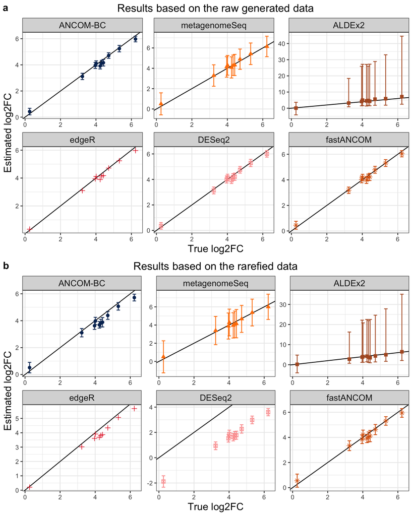

```r
ep2rr <- ggarrange(ep2, ep2r, nrow=2, labels = c('a', 'b'))
ep2rr
```

```r
# ggsave('/Users/zhouchao/R/fastANCOM/ToydataResults_S1-S5/S5_log2FC_1.pdf',
#       ep2rr,
#       width = 8, height = 9)
```

- **comparsion between the results based on the raw and rarefied data**

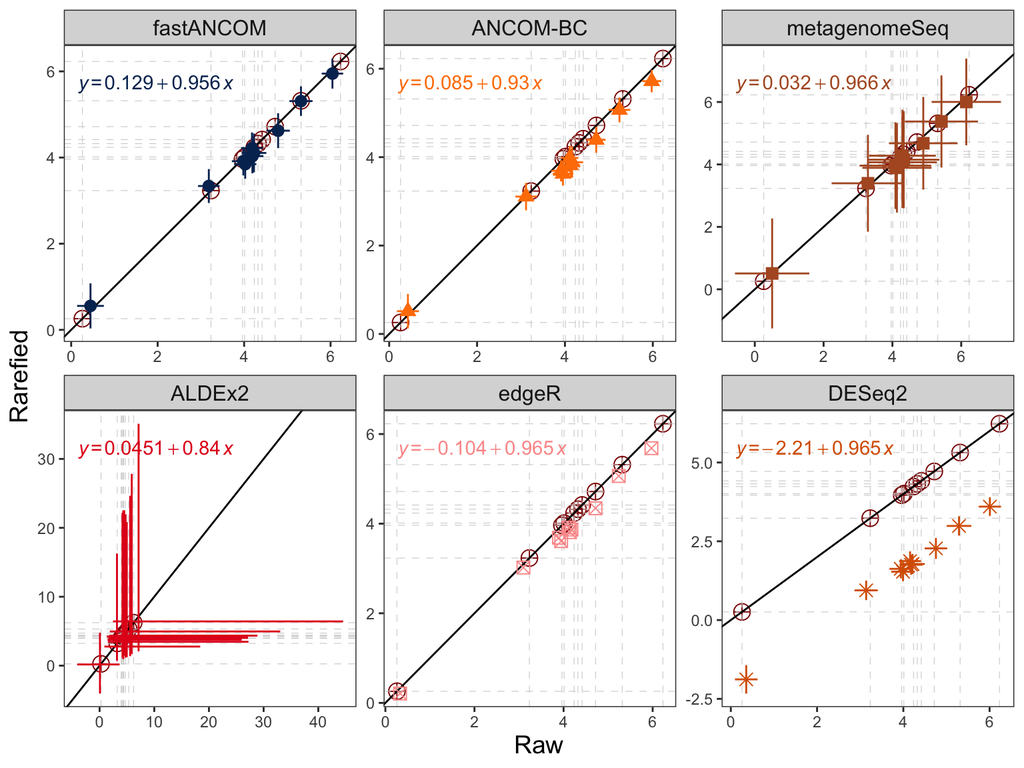

```r
tmpb <- data.frame(Microbe=factor(1:10),
        log2FC=c(b, fit[1:10, 1],ancombc_res$beta[1:10],zig_res$logFC[1:10],
        aldex2_res$effect[1:10],edger_res$logFC[1:10],deseq2_res$log2FoldChange[1:10]),
        Type=c(rep(bmethods, each=10)))
tmpb$ymin <- c(rep(NA, 10), fit[1:10, 1]-2*fit[1:10, 2],
               ancombc_res$beta[1:10]-2*ancombc_res$se[1:10],
               zig_res$logFC[1:10]-2*zig_res$se[1:10],
               aldex2_res$effect.low[1:10], rep(NA, 10),
               deseq2_res$log2FoldChange[1:10]-2*deseq2_res$lfcSE[1:10])
tmpb$ymax <- c(rep(NA, 10), fit[1:10, 1]+2*fit[1:10, 2],
               ancombc_res$beta[1:10]+2*ancombc_res$se[1:10],
               zig_res$logFC[1:10]+2*zig_res$se[1:10],
               aldex2_res$effect.high[1:10], rep(NA, 10),
               deseq2_res$log2FoldChange[1:10]+2*deseq2_res$lfcSE[1:10])
tmpb$Type <- factor(tmpb$Type, levels = bmethods)

tmpbr <- data.frame(Microbe=factor(1:10),
      log2FC=c(b, fitr[1:10, 1],ancombc_resr$beta[1:10],zig_resr$logFC[1:10],
    aldex2_resr$effect[1:10],edger_resr$logFC[1:10],deseq2_resr$log2FoldChange[1:10]),
    Type=c(rep(bmethods, each=10)))
tmpbr$ymin <- c(rep(NA, 10), fitr[1:10, 1]-2*fitr[1:10, 2],
               ancombc_resr$beta[1:10]-2*ancombc_resr$se[1:10],
               zig_resr$logFC[1:10]-2*zig_resr$se[1:10],
               aldex2_resr$effect.low[1:10], rep(NA, 10),
               deseq2_resr$log2FoldChange[1:10]-2*deseq2_resr$lfcSE[1:10])
tmpbr$ymax <- c(rep(NA, 10), fitr[1:10, 1]+2*fitr[1:10, 2],
               ancombc_resr$beta[1:10]+2*ancombc_resr$se[1:10],
               zig_resr$logFC[1:10]+2*zig_resr$se[1:10],
               aldex2_resr$effect.high[1:10], rep(NA, 10),
               deseq2_resr$log2FoldChange[1:10]+2*deseq2_resr$lfcSE[1:10])
tmpbr$Type <- factor(tmpbr$Type, levels = bmethods)

tmpb12 <- data.frame(Microbe=factor(1:10), type=tmpbr$Type,
                     betax=tmpb$log2FC,  xmin=tmpb$ymin,  xmax=tmpb$ymax,
                     betay=tmpbr$log2FC, ymin=tmpbr$ymin, ymax=tmpbr$ymax)

gb12 <- ggplot(data=tmpb12[tmpb12$type!='Truth', ],
               aes(x=betax,y=betay, shape=type, color=type)) +
  geom_point(aes(x=rep(b,6), y=rep(b,6)),
             color='darkred', size=4, shape=10, face='blod') +
  geom_hline(yintercept = b, color='lightgrey', linetype="dashed", size=0.2) +
  geom_vline(xintercept = b, color='lightgrey', linetype="dashed", size=0.2) +
  geom_abline(intercept = 0, slope = 1) + geom_point(size=3) +
  geom_errorbar(aes(ymin=ymin, ymax=ymax, color=type)) +
  geom_errorbarh(aes(xmin=xmin, xmax=xmax, color=type)) +
  theme_bw() + labs(x='Raw', y='Rarefied') +
  scale_color_manual(values = cols) +
  theme(legend.title = element_blank(), legend.position='none',
        strip.text.x = element_text(size=12), axis.title = element_text(size=14),
        panel.grid.major=element_blank(),panel.grid.minor=element_blank())
gb12 + facet_wrap(.~type, nrow=2, scale='free') +
   stat_poly_eq(aes(label = ..eq.label..),label.y = 0.9,
                formula = y ~ x, parse = TRUE)
```